# Quesion 10

## Evaluating Model Performance

Create the predicted probabilities from the SMS classifier built in Chapter 4. Obtain the predicted probabilities

```
              ham         spam
[1,] 9.999996e-01 4.001744e-07
[2,] 9.999922e-01 7.818488e-06
[3,] 9.998554e-01 1.446003e-04
[4,] 9.999614e-01 3.859165e-05
[5,] 4.312258e-10 1.000000e+00
[6,] 9.998517e-01 1.482769e-04
```

Combine the results into a data frame

```r
sms_results <- data.frame(actual_type = sms_test_labels,
                          predict_type = sms_test_pred,
                          prob_spam = round(sms_test_prob[ , 2], 5),
                          prob_ham = round(sms_test_prob[ , 1], 5))
write.csv(sms_results, "sms_results.csv", row.names = FALSE)
```

Confusion matrixes in R

The first several test cases

`r`r head(sms_results)

|  | actual_type | predict_type | prob_spam | prob_ham |
| --- | --- | --- | --- | --- |
| 1 | ham | ham | 0.00000 | 1.00000 |
| 2 | ham | ham | 0.00001 | 0.99999 |
| 3 | ham | ham | 0.00014 | 0.99986 |
| 4 | ham | ham | 0.00004 | 0.99996 |
| 5 | spam | spam | 1.00000 | 0.00000 |
| 6 | ham | ham | 0.00015 | 0.99985 |

Test cases where the model is less confident

`r`r head(subset(sms_results, prob_spam > 0.40 & prob_spam < 0.60))

|  | actual_type | predict_type | prob_spam | prob_ham |
| --- | --- | --- | --- | --- |
| 717 | ham | spam | 0.51257 | 0.48743 |
| 732 | spam | ham | 0.49833 | 0.50167 |
| 1311 | ham | spam | 0.54022 | 0.45978 |
| 1324 | spam | spam | 0.53292 | 0.46708 |

Test cases where the model was wrong

`r`r head(subset(sms_results, actual_type != predict_type))

|  | actual_type | predict_type | prob_spam | prob_ham |
| --- | --- | --- | --- | --- |
| 53 | spam | ham | 0.00064 | 0.99936 |
| 59 | spam | ham | 0.00354 | 0.99646 |
| 73 | spam | ham | 0.01299 | 0.98701 |
| 76 | spam | ham | 0.00622 | 0.99378 |
| 184 | spam | ham | 0.01583 | 0.98417 |
| 187 | ham | spam | 0.72218 | 0.27782 |

Specifying vectors

`r`r table(sms_results$actual_type, sms_results$predict_type)

```
        ham spam
  ham  1201    6
  spam   30  153
```

Alternative solution using the formula interface

`r`r xtabs(~ actual_type + predict_type, sms_results)

```
           predict_type
actual_type  ham spam
       ham  1201    6
       spam   30  153
```

Using the CrossTable function

`r`r library(gmodels) CrossTable(sms_results$actual_type, sms_results$predict_type)

```
   Cell Contents
|-------------------------|
|                       N |
| Chi-square contribution |
|           N / Row Total |
|           N / Col Total |
|         N / Table Total |
|-------------------------|


Total Observations in Table:  1390


                        | sms_results$predict_type
sms_results$actual_type |       ham |      spam | Row Total |
------------------------|-----------|-----------|-----------|
                    ham |      1201 |         6 |      1207 |
                        |    16.317 |   126.328 |           |
                        |     0.995 |     0.005 |     0.868 |
                        |     0.976 |     0.038 |           |
                        |     0.864 |     0.004 |           |
------------------------|-----------|-----------|-----------|
                   spam |        30 |       153 |       183 |
                        |   107.620 |   833.210 |           |
                        |     0.164 |     0.836 |     0.132 |
                        |     0.024 |     0.962 |           |
                        |     0.022 |     0.110 |           |
------------------------|-----------|-----------|-----------|
           Column Total |      1231 |       159 |      1390 |
                        |     0.886 |     0.114 |           |
------------------------|-----------|-----------|-----------|
```

Accuracy and error rate calculation Accuracy

`r`r (152 + 1203) / (152 + 1203 + 4 + 31)

```
[1] 0.9748201
```

Error rate

`r`r (4 + 31) / (152 + 1203 + 4 + 31)

```
[1] 0.02517986
```

Error rate = 1 - accuracy

`r`r 1 - 0.9748201

```
[1] 0.0251799
```

Beyond accuracy: other performance measures

`r`r library(caret)

[output not shown]

Kappa statistic example using SMS classifier

`r`r pr_a <- 0.865 + 0.109 pr_a

```
[1] 0.974
```

`r`r pr_e <- 0.868 * 0.888 + 0.132 * 0.112 pr_e

```
[1] 0.785568
```

`r`r k <- (pr_a - pr_e) / (1 - pr_e) k

```
[1] 0.8787494
```

Calculate kappa via the vcd package

`r`r library(vcd)

`r`r Kappa(table(sms_results$actual_type, sms_results$predict_type))

```
            value     ASE     z Pr(>|z|)
Unweighted 0.8801 0.01962 44.85        0
Weighted   0.8801 0.01962 44.85        0
```

Calculate kappa via the irr package

`r`r library(irr)

`r`r kappa2(sms_results[1:2])

```
 Cohen's Kappa for 2 Raters (Weights: unweighted)

 Subjects = 1390
   Raters = 2
    Kappa = 0.88

        z = 32.9
  p-value = 0
```

`r`r sens <- 152 / (152 + 31) sens

```
[1] 0.8306011
```

`r`r spec <- 1203 / (1203 + 4) spec

```
[1] 0.996686
```

Sensitivity and specificity example using SMS classifier example using the caret package

```
[1] 0.8360656
```

```
[1] 0.995029
```

Precision and recall

`r`r prec <- 152 / (152 + 4) prec

```
[1] 0.974359
```

`r`r rec <- 152 / (152 + 31) rec

```
[1] 0.8306011
```

Example using the caret package

```
[1] 0.9622642
```

```
[1] 0.8360656
```

F-measure

`r`r f <- (2 * prec * rec) / (prec + rec) f

```
[1] 0.8967552
```

`r`r f <- (2 * 152) / (2 * 152 + 4 + 31) f

```
[1] 0.8967552
```

Visualizing Performance Tradeoffs

`r`r library(pROC)

`r`r sms_roc <- roc(sms_results$actual_type, sms_results$prob_spam)

ROC curve for Naive Bayes

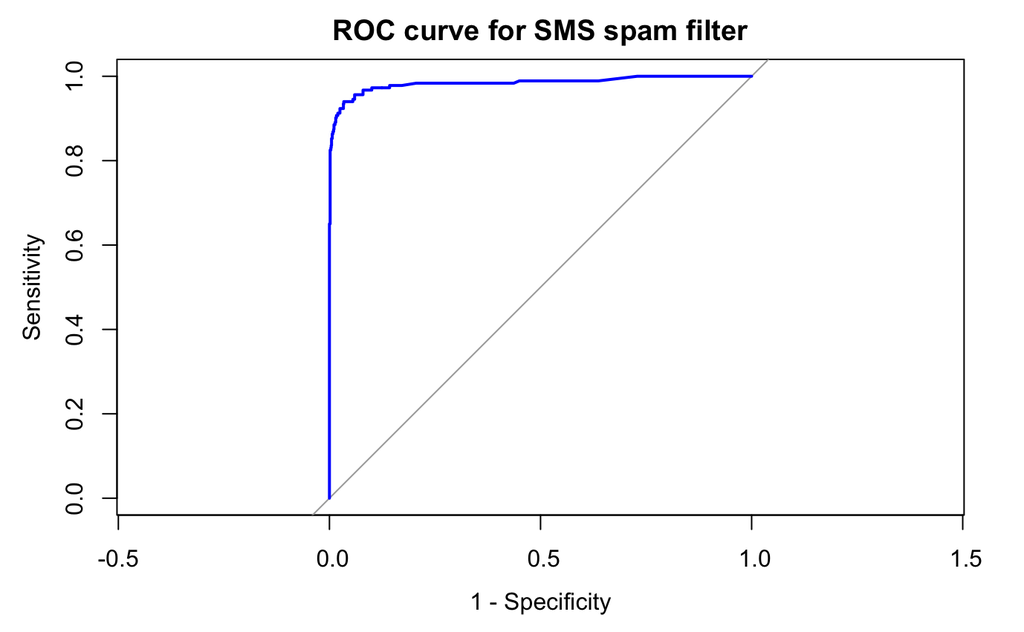

Compare to kNN

[figure not shown]

Calculate AUC for Naive Bayes and kNN

`r`r auc(sms_roc)

```
Area under the curve: 0.984
```

`r`r auc(sms_roc_knn)

```
Area under the curve: 0.8942
```

Estimating Future Performance and partitioning data

Holdout method using random IDs

`r`r random_ids <- order(runif(1000)) credit_train <- credit[random_ids[1:500],] credit_validate <- credit[random_ids[501:750], ] credit_test <- credit[random_ids[751:1000], ]

Using caret function

`r`r in_train <- createDataPartition(credit$default, p = 0.75, list = FALSE) credit_train <- credit[in_train, ] credit_test <- credit[-in_train, ]

10-fold CV

`r`r folds <- createFolds(credit$default, k = 10) str(folds)

```
List of 10
 $ Fold01: int [1:100] 26 31 58 65 68 73 82 86 89 92 ...
 $ Fold02: int [1:100] 5 23 24 27 29 32 39 45 48 56 ...
 $ Fold03: int [1:100] 4 6 7 13 18 22 52 53 81 101 ...
 $ Fold04: int [1:100] 1 2 11 15 46 93 109 120 129 139 ...
 $ Fold05: int [1:100] 14 16 25 36 43 50 57 61 67 71 ...
 $ Fold06: int [1:100] 20 42 69 74 75 77 83 85 108 132 ...
 $ Fold07: int [1:100] 3 10 12 21 70 79 84 87 98 116 ...
 $ Fold08: int [1:100] 19 28 30 33 34 35 37 47 49 55 ...
 $ Fold09: int [1:100] 8 9 17 38 41 44 54 59 60 64 ...
 $ Fold10: int [1:100] 40 51 66 94 96 102 111 117 130 146 ...
```

`r`r credit01_test <- credit[folds$Fold01, ] credit01_train <- credit[-folds$Fold01, ]

Automating 10-fold CV for a C5.0 Decision Tree using `lapply()`

Use an older random number generator to match the book

```
non-uniform 'Rounding' sampler used
```

`r`r set.seed(123) folds <- createFolds(credit$default, k = 10)

cv_results <- lapply(folds, function(x) { credit_train <- credit[-x, ] credit_test <- credit[x, ] credit_model <- C5.0(default ~ ., data = credit_train) credit_pred <- predict(credit_model, credit_test) credit_actual <- credit_test$default kappa <- kappa2(data.frame(credit_actual, credit_pred))$value return(kappa) })

str(cv_results)

```
List of 10
 $ Fold01: num 0.343
 $ Fold02: num 0.255
 $ Fold03: num 0.109
 $ Fold04: num 0.107
 $ Fold05: num 0.338
 $ Fold06: num 0.474
 $ Fold07: num 0.245
 $ Fold08: num 0.0365
 $ Fold09: num 0.425
 $ Fold10: num 0.505
```

`r`r mean(unlist(cv_results))

```
[1] 0.283796
```